# Puerto Rico Reasonable Potential (RP) Calculator

User Guide — Version 1.0.0

# Overview

The **Puerto Rico Reasonable Potential (RP) Calculator** is a web-based application designed to support EPA Region 2 permit writers in determining whether reasonable potential (RP) exists for an NPDES-permitted discharge to cause or contribute to an exceedance of Puerto Rico’s water quality standards (WQS). The application automates the most data-intensive steps of the RP analysis: retrieving effluent monitoring data from a local copy of EPA’s ICIS-NPDES database, aligning those data with the applicable Puerto Rico WQS, performing the statistical projection described in the EPA Technical Support Document for Water Quality-Based Toxics Control (TSD, 1991) where appropriate, and generating a documented, reproducible PDF report.

The application is scoped to **Puerto Rico NPDES permits** and references the **Puerto Rico Water Quality Standards Regulation (PRWQSR), as amended April 2025** (DNER Resolution R-25-006). All numeric criteria, water classifications, and hardness-dependent metal limits applied by the app are drawn directly from that regulation.

**Note**

**Where the data come from.** The app does not call a live web service at analysis time. A companion script (`refresh_db.R`) pulls PR/VI facility and DMR records from the ICIS-NPDES Oracle database on a weekly schedule and writes them to a local SQLite file (`data/pr_rp.sqlite`) that the app reads. This makes the app fast and reproducible: two analyses run against the same weekly snapshot return the same result. The refresh date therefore bounds how current the data can be; the landing page shows when the snapshot was last updated and how many facilities and DMR records it holds.

**Note**

## What the App Does

For each pollutant and outfall combination at a selected facility, the app:

1. Retrieves the DMR values whose **reporting statistic** matches what each criterion is written against — the maximum for most ceiling criteria, the minimum for floor criteria such as dissolved oxygen and pH, and the geometric mean or 90th percentile for interval-based bacteria criteria — or accepts locally supplied data
2. Checks reported units against the WQS unit and converts where a conversion is defined
3. For criteria evaluated by statistical projection, calculates a **Receiving Water Concentration (RWC)** using the multiplying factor (MF) method from TSD Section 3.3.2
4. For criteria evaluated by direct comparison, compares the appropriate observed statistic to the criterion with no multiplying factor and no dilution
5. Compares the result to the applicable criterion from the PRWQSR for each selected water classification and returns a **YES / NO / DEPENDS** RP determination for each pollutant × outfall × water class combination
6. Generates a PDF report — and optionally a ZIP package with supporting data — that documents all inputs, settings, and findings

**Note**

**Not every criterion is a ceiling.** Projecting a maximum concentration through the TSD multiplying factor is correct for most pollutants but wrong for several important ones — dissolved oxygen (a floor), Enterococci (interval statistics), color and turbidity (direct comparison), oil & grease (narrative), and pH and temperature. Each crosswalk row declares its own evaluation semantics, so the app applies the right test to each parameter. Section 8.2 describes the parameters that are evaluated by direct comparison rather than projection.

## What the App Does Not Replace

The app is an analytical aid, not a substitute for permit writer judgment. It does not:

- Perform whole effluent toxicity (WET) analysis
- Calculate waste load allocations (WLAs) or mixing zone analyses
- Account for background receiving water concentrations
- Evaluate narrative water quality criteria beyond a simple detection screen
- Perform a Streeter-Phelps dissolved-oxygen analysis (see Section 8.2.3)
- Replace the fact sheet or other permit development documentation requirements

When the app returns a YES RP finding, the permit writer must still determine the appropriate effluent limitation based on the applicable water quality standard, the dilution ratio, and any mixing zone authorization. When it returns NO, that finding is based on the statistical projection or direct comparison alone and should be considered alongside other factors described in 40 CFR 122.44(d)(1). A **DEPENDS** finding means an excursion was not observed but the absence of one cannot, by itself, rule out reasonable potential for that parameter (see Section 9.3 and Section 8.2).

# Regulatory Background

## Reasonable Potential Under the Clean Water Act

Under 40 CFR 122.44(d)(1)(i), NPDES permits must include effluent limits for pollutants that are or may be discharged at levels that will cause, have the reasonable potential to cause, or contribute to an excursion above any applicable water quality standard. Determining whether a discharge has “reasonable potential” is therefore a required step in permit development for any parameter that is monitored at an outfall.

EPA’s 1991 Technical Support Document for Water Quality-Based Toxics Control (TSD) provides the recommended methodology for making this determination using effluent monitoring data. The core question is whether the upper bound of the expected effluent concentration distribution, projected into the receiving water accounting for dilution, could exceed the applicable criterion. The statistical approach in the TSD uses the coefficient of variation (CV) of the effluent data and the number of samples to construct this projection, with the lognormal distribution used as the basis for the multiplying factors.

## The Puerto Rico Water Quality Standards Regulation

The PRWQSR, administered by Puerto Rico’s Department of Natural and Environmental Resources (DNER), establishes the water quality standards that NPDES permits in Puerto Rico must protect. The regulation classifies Puerto Rico’s waters by designated use and sets numeric criteria for a wide range of pollutants. The 2025 amendment (Resolution R-25-006, effective June 27, 2025) is the currently applicable version.

The standards that drive RP determinations fall into several categories as implemented in the app:

- **Fixed numeric criteria** — a single concentration limit for a given pollutant and water classification (e.g., arsenic in Class SB at 36 µg/L)
- **Hardness-dependent criteria** — applicable to seven metals in Class SD waters; the criterion is computed from the receiving water hardness using regression equations specified in Rule 1303.1(J)(1) (see Section 8.3)
- **Condition-dependent criteria** — applicable to Total Ammonia Nitrogen (TAN) in Class SD waters; the criterion varies with receiving water pH and temperature as specified in Rule 1303.2(C)(2)(l) (see Section 8.4)
- **Range and floor criteria** — pH must stay within a range, and dissolved oxygen must stay above a floor. These are evaluated by direct comparison, not projection (see Section 8.2)
- **Interval and narrative criteria** — Enterococci criteria are frequency- and interval-based statistics, and oil & grease is a narrative “substantially free from” standard (see Section 8.2.5 and Section 8.2.6)

Three Class SD parameters — total nitrogen, total phosphorus, and selenium — carry **separate criteria depending on whether the receiving water is a stream or a reservoir/lake**. The app reports these as distinct water-class lines (e.g., *class SD waters — stream* vs *class SD waters — reservoir/lake*) so the permit writer can see which receiving-water type drives a finding.

## Water Classifications Relevant to NPDES Permitting

The PRWQSR classifies Puerto Rico’s waters into several categories. The app includes the four classifications most relevant to NPDES point source discharges. Understanding these classifications is important because the applicable criterion — and therefore the RP determination — differs by classification.

**Class SB — Coastal and Estuarine Waters** Class SB encompasses all coastal and estuarine waters of Puerto Rico not designated as the more protective Class SA (which includes the bioluminescent lagoons and other waters of exceptional ecological value where point source discharges are not permitted). Class SB extends from mean sea level to a maximum of approximately 10.35 miles offshore and includes associated wetlands. Designated uses include primary and secondary contact recreation, and propagation and maintenance of desirable species including threatened and endangered species. Most NPDES-permitted facilities discharging to coastal waters in Puerto Rico discharge to Class SB receiving waters.

**Class SD — Surface Waters** Class SD covers all surface waters of Puerto Rico — streams, rivers, lakes, reservoirs, and inland water bodies — except those designated as the more protective Class SE (Laguna Tortuguero and Laguna Cartagena). Designated uses include use as a raw source of public water supply, propagation and maintenance of desirable species, and primary and secondary contact recreation. Class SD criteria are generally more stringent than Class SB for most parameters because of the drinking water supply designation. Several criteria under Class SD depend on receiving water hardness (for metals) or on pH and temperature (for TAN), and a few distinguish stream from reservoir/lake receiving waters.

**Class SG — Ground Waters** Class SG includes all ground waters of Puerto Rico, including those that discharge into coastal, surface, and estuarine waters. Designated uses are drinking water supply and agricultural use including irrigation. Ground water criteria are typically the drinking water (DW) or human health (HH) values, whichever is more stringent given the receiving water body into which the ground water flows.

**Surface Waters (general)** In the app’s water type filter, “Surface Waters” maps to the PRWQSR’s general surface water standards (Rule 1303.1) that apply across all surface water classifications, as distinct from the class-specific criteria under Rule 1303.2. The general standards include temperature, asbestos, radium-226, strontium-90, gross beta, and oil & grease.

**Note**

**Selecting water classifications in the app:** The water classification selection determines which WQS rows from the crosswalk are active for both data filtering and RP comparison. Selecting multiple classifications produces an RP determination for each class independently — one row per class in the Findings table and the report — and the Findings plot summarizes the worst case across them. The general-standard parameters (temperature, oil & grease, and the others listed above) appear **only** when “Surface Waters” or “All” is selected — narrowing to a single specific class will not pull them in. When in doubt about which classification applies to a receiving water body, consult the PRWQSR classification maps (Rule 1302) or contact the DNER Water Quality Program.

# Getting Started

## Two Workflows at a Glance

The app offers two entry points depending on whether the facility appears in the local ICIS-NPDES database.

|  | **NPDES Workflow** | **Standalone Workflow** |
| --- | --- | --- |
| **Best for** | Existing permitted facilities | New permits, reissuances with no prior ID, or supplementing the database with local measurements |
| **Data source** | Local ICIS-NPDES database (weekly refresh) | User-supplied CSV using the app’s template |
| **Requires** | NPDES permit ID | Completed DMR template |
| **Can supplement with local data** | Yes — via the Append DMR function | N/A — local data is the primary source |

Both workflows share the same Analysis Settings, Findings, and Report pages. The only difference is how effluent data are loaded.

## Navigating the App

The app uses a single-page layout with page routing. A persistent top bar appears on every page with the app title and version, a **← Back to Start** button (returns to the landing page), and a **User Guide** button (opens this document in a modal window). Within each page you also move using contextual buttons (e.g., “Return Home,” “← Back to Search,” “← Back to Settings”).

The landing page offers the two workflows, shows when the ICIS-NPDES snapshot was last updated, and has a **Download User Guide PDF** button for a printable copy of this guide.

# NPDES Workflow

Use this workflow when the facility has an active NPDES permit and effluent monitoring data available in the local ICIS-NPDES database.

## Step 1: Search and Select a Facility

Click **Connect to ICIS-NPDES** on the landing page. This opens the facility selection page, which loads the list of NPDES permits for Puerto Rico from the local ICIS-NPDES database at application startup.

Use the **Search Permit ID or Facility Name** box to find the facility of interest. You can type either the NPDES ID (e.g., `PR0001031`) or any part of the facility name — the search is case-insensitive and matches partial strings. Select the facility from the dropdown. If the facility list cannot be loaded (for example, the database file is missing), a warning with a **↺ Retry** button appears above the search box.

Once a facility is selected:

- The **map** displays a marker at the facility’s reported latitude/longitude from the facility record in the local database
- The **Facility Details** table displays key permit attributes from that facility record
- The **Settings** panel and **Fetch DMR Data** button become visible

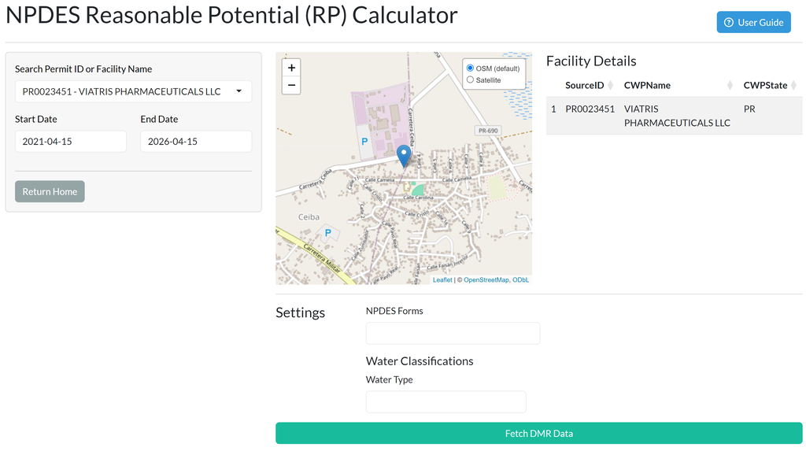

Facility selection page showing the search box, map with marker, and Facility Details table

Set the **date range** for DMR retrieval using the Start Date and End Date inputs. The default range is the five years prior to today’s date, which is appropriate for most permit reissuances. The date range controls which DMR records are pulled from the database — it does not filter the facility list.

**Note**

**Selections persist within your session:** If you navigate away from the search page and return — for example, to revise a search — your permit ID, date range, NPDES forms, and water classification are retained. These reset only when the app is restarted. Analysis Settings on the Summary page (hardness, pH, temperature, dilution ratio, confidence level) are not persisted, because they re-select naturally when a different permit is fetched.

## Step 2: Configure Filters

Before fetching data, configure the two filters that control which parameters are highlighted and which WQS criteria are in scope.

### NPDES Forms

Select one or more **NPDES application forms** from the multi-select dropdown. At least one form must be selected — the Coverage Summary is built from the selected forms. NPDES applications require permittees to report specific pollutants depending on the type of facility and the nature of the discharge. The dropdown lists the EPA application forms covered by the app’s pollutant table, for example:

- **Form 2C** — Existing manufacturing, commercial, mining, and silviculture facilities
- **Form 2D** — New manufacturing, commercial, mining, and silviculture facilities
- **Form 2F** — Stormwater discharges associated with industrial activity

The form selection defines the **universe of pollutants** expected to be reported for the facility. It determines which pollutants appear in the Data Overview (Coverage Summary) table and the *Basis for Inclusion* column of the report’s Included Pollutants table.

**Important**

**Form selection is a display filter, not an analysis filter.** Any parameter that has DMR data and an applicable WQS criterion is evaluated for RP regardless of its form association. Parameters not associated with a selected form still appear in the Coverage Summary and are still analyzed; the report records them as included because prior DMR data exist (*Existing DMR*).

**Tip**

**Selecting the right form:** If you are unsure which form applies, refer to the facility’s permit application or its permit record. Most industrial and manufacturing dischargers use Form 2C or 2D, plus Form 2F for stormwater associated with industrial activity. When multiple forms apply, select all of them.

### Water Classifications

Select one or more **water classifications** from the multi-select dropdown. The choices correspond to Puerto Rico’s PRWQSR classifications described in Section 2.3:

| Selection | Maps to PRWQSR Classification |
| --- | --- |
| All | All classes in the crosswalk |
| Class SB | Class SB coastal and estuarine waters |
| Class SD | Class SD surface waters (including drinking water subclass) |
| Class SG | Class SG ground waters |
| Surface Waters | General surface water standards (Rule 1303.1) |

These selections determine which WQS criteria rows are active for comparison. The default is **Class SB**. When multiple classifications are selected, the app performs the RP comparison independently for each class. Select **All** to evaluate against every applicable standard in the crosswalk — appropriate when the receiving water classification is uncertain or when you want to be comprehensive.

**Important**

**Class SD and conditional criteria:** If **Class SD** is selected, the *Receiving Water Inputs (Class SD)* panel appears in the Analysis Settings (see Section 4.6.3). It holds the hardness used for the hardness-dependent metals and the pH and temperature used for the TAN criterion. This panel is only shown for Class SD because those criteria are specific to Class SD surface waters under the PRWQSR.

## Step 3: Fetch DMR Data

Click **Fetch DMR Data**. The app queries the local ICIS-NPDES database for effluent monitoring records matching the selected permit ID and date range, then applies the following processing steps automatically:

**Statistic tagging:** Each DMR record is tagged with a semantic statistic token (daily maximum, daily minimum, geometric mean, 90th percentile, or average) derived from its ICIS statistical-base code. This is what lets the app keep the right records for each criterion — the minimum for a floor parameter, the geometric mean for a bacteria criterion — instead of keeping only maximums. A parameter with data but no matching criterion is retained rather than discarded, so it can be surfaced on the Needs Attention tab (see Section 4.5) rather than vanishing silently.

**Unit filling:** DMR reports occasionally omit unit labels, particularly on no-discharge (NODI B/Q) rows. A no-discharge row with a blank unit takes the most frequently reported unit for that parameter in the permit’s records. If every record for a parameter is missing its unit, the WQS unit from the crosswalk is used.

**Unit conversion:** Each reported value is checked against the WQS unit for its parameter. The converter handles concentration conversions (µg/L ↔︎ mg/L, ng/L → µg/L or mg/L, ppm → mg/L or µg/L) and recognizes several units that are written differently but mean the same thing (e.g., ICIS long-form bacteria and color units). Mass-load and flow units (e.g., kg/day, MGD) are **excluded** from the WQS comparison by design rather than treated as errors, because a load cannot be compared to a concentration criterion. When a parameter has no WQS criterion for the selected water class, its records are flagged **NO WQS**. A genuinely unrecognized unit is flagged **FAIL** and the value is retained at face value. Every status is shown in the Coverage Summary (see Section 4.4).

**Code merging:** Some analytes are reported under more than one DMR code. Temperature reported in °F (code 00011) is converted to °C and merged into code 00010; when a permittee reports both °F and °C for the same outfall and period, the converted °F record is kept and the °C record dropped. The ammonia codes 82230 and 00609 are merged into 00610 (see Section 8.4). The original code is kept with each record and appears in the DMR sheet of the data package.

**Warning**

**Fahrenheit conversion is not checked against the values.** The °F → °C conversion trusts the parameter code. If a permittee entered Celsius numbers under the Fahrenheit code, the converted values come out far too low — often below freezing. The app does not try to correct this; instead the report flags any outfall with temperatures below 0 °C (see Section 7.2). Verify such records against the DMR before relying on the temperature result.

After a successful fetch, the app navigates to the **Summary (Data Overview) page**.

## Step 4: Review the Data Overview

The Data Overview page displays the **Coverage Summary** table, which lists the pollutants relevant to this analysis — those associated with the selected NPDES forms plus any additional parameters that have DMR data — alongside a count of available DMR samples and a unit conversion status indicator. Above the table, the app shows the most recent monitoring period available in the database for this permit, independent of the date range you selected.

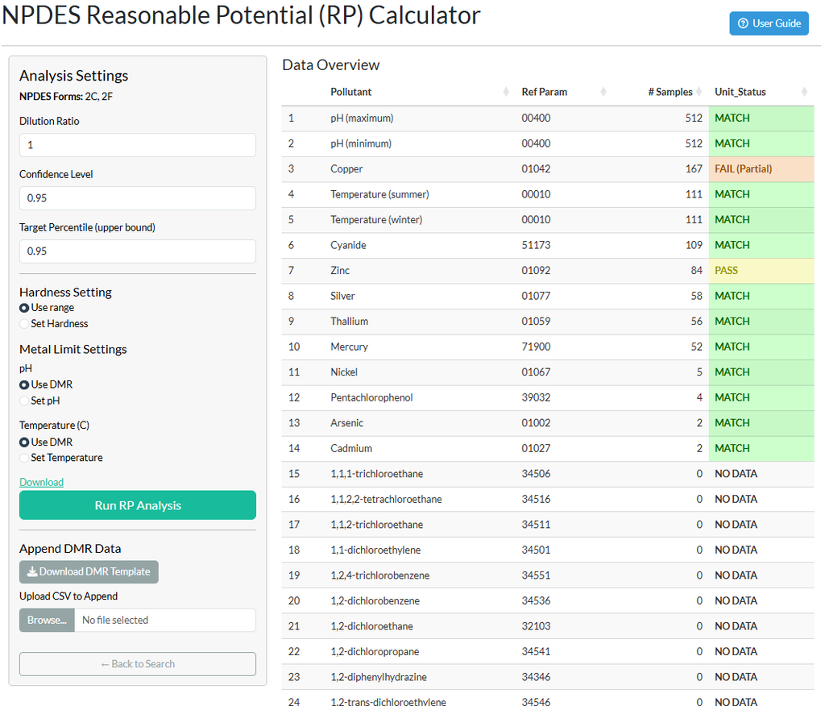

Summary page showing the Coverage Summary table with unit status column

**Understanding the Coverage Summary columns:**

| Column | Description |
| --- | --- |
| Pollutant | NPDES pollutant name from the form crosswalk |
| Ref Param | The DMR parameter code(s) matched to this pollutant in the crosswalk |
| # Samples | Count of qualifying DMR records retrieved for this permit and date range, across all outfalls |
| Unit Status | Result of the unit conversion check (see below) |

**Unit Status values:**

| Status | Meaning | Action |
| --- | --- | --- |
| MATCH | Reported units already match the WQS unit (including recognized aliases) — no conversion needed | None required |
| PASS | Units differed but a multiplicative or temperature conversion was successfully applied | Conversion is shown in the report |
| FAIL (Partial) | Some eligible records converted successfully but others could not | Proceed with caution; non-convertible records are dropped from the RP calculation |
| FAIL | No eligible record could be converted to the WQS unit (unrecognized unit) | Investigate the DMR data; values are retained at face value but dropped from RP |
| EXCLUDED | Every record is a mass-load or flow unit (e.g., kg/day, MGD) | Informational — these cannot be compared to a concentration criterion and are excluded by design |
| NO WQS | No WQS criterion exists for this parameter in the selected water class | Informational — see the **Needs Attention** tab to add a manual criterion if appropriate |
| NO DATA | Parameter is in the crosswalk but had no DMR records | Informational — nothing to evaluate |

EXCLUDED, NO WQS, and NO DATA are informational, not errors, and are color-coded distinctly (grey / blue-grey / light-grey) from the FAIL states (red / orange). A FAIL or FAIL (Partial) status does not prevent the analysis from running, but it means that some or all values for that parameter may be in the wrong units. Before proceeding, verify the DMR data in the source ICIS-NPDES record for any parameters showing a FAIL status — the issue is often a data entry error in the original submission.

## Step 4b: Resolve Parameters Needing Attention

The Summary page has three tabs: **Data Overview** (the Coverage Summary described above), **⚠ Needs Attention**, and **WQS Reference**.

The **Needs Attention** tab lists any parameter that has DMR data but no usable WQS criterion for the selected water class. Each flagged parameter is shown in an orange-bordered card with the reason it was flagged:

- **Wrong water class** — a WQS criterion exists for this parameter, but not for the class(es) you selected.
- **No crosswalk entry** — the parameter code has no WQS entry at all.
- **Missing criterion value** — a crosswalk entry exists but its value is blank.
- **Reported statistic does not match criterion** — the parameter matches a criterion, but its DMR data reports only a statistic the criterion is not written against (for example, a daily maximum reported against a geometric-mean criterion). This is a matched code, so it is added to the flagged set rather than dropped.

For each flagged parameter you choose **Include with manual WQS** or **Exclude from analysis** using the radio buttons. To include a parameter, fill in the manual-entry fields: a **Criterion Value**, a **Unit** (limited to units the converter can handle), a **Criterion Type** (e.g., *Aquatic Life – Acute*), a **Criterion Direction**, the **Water Class(es)** it applies to, and a required **Basis / Notes** field. To exclude a parameter, provide a required reason. Included parameters are injected as manual criteria when you run the analysis; excluded parameters are recorded in the report’s *Excluded Parameters* section for the permanent record.

**Note**

**Criterion Direction — ceiling vs floor.** The direction selector offers *Ceiling — shall not exceed (>)* and *Floor — shall not fall below (<)*. This matters because a hand-entered floor standard (a dissolved-oxygen-style minimum) would otherwise be treated as a ceiling and projected incorrectly. A floor entry is evaluated by direct comparison against the observed **minimum**, and a value exactly on the criterion is treated as compliant (the comparison is a strict inequality). Known parameters re-added by hand inherit their built-in profile — a direct parameter stays direct — so the direction selector governs genuinely new parameters.

**Note**

**Green alias hints.** Some cards show a green **Hint** pointing to the code and value that applies — for example, when the criterion for an analyte lives under a synonym parameter code that differs from the one the permittee reported. The hint tells you which criterion ID and value to enter rather than making you hunt for it. Use the **WQS Reference** tab — a read-only, searchable view of the full crosswalk — to confirm criterion IDs and values before entering a manual criterion.

**Important**

**Run RP is gated on resolution.** The **Run RP Analysis** button stays disabled until every flagged parameter has an Include/Exclude decision. If you need to proceed without resolving them, use the red **⚡ Quick Run (Drop Unresolved)** button — it auto-excludes all unresolved parameters and stamps a prominent “preliminary report” warning on the generated report so the omission is on the permanent record.

Parameters that don’t require resolution are never flagged: hardness-dependent metals and TAN (whose criteria are computed at run time from your hardness, pH, and temperature inputs) are treated as matched, and parameters reported only in mass-load or flow units are dropped from the flag pass because they can never be compared to a concentration criterion.

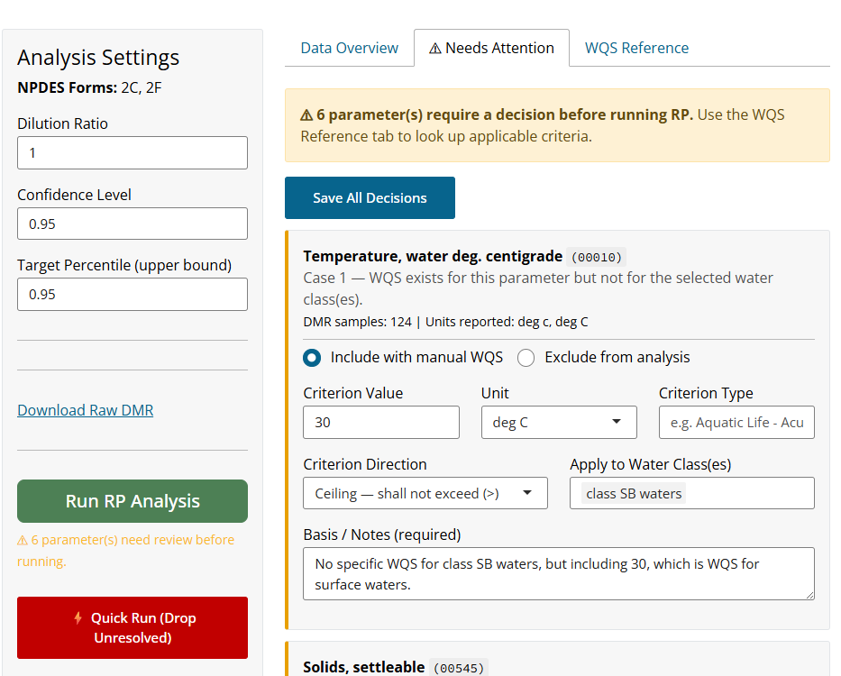

## Step 5: Configure Analysis Settings

The left panel of the Summary page contains the Analysis Settings. These control the statistical and receiving water parameters used in the RWC and RP calculations. A full description of the methodology behind each setting is provided in Section 8.

### Dilution Ratio

The **Dilution Ratio** (DR) is the ratio of the total flow at the edge of the mixing zone (effluent plus receiving water) to the effluent flow alone. It represents the degree to which the discharge is diluted by the receiving water at the point of compliance. The default value is 1, which means no dilution is assumed — the effluent concentration itself is compared to the WQS criterion. This is the conservative default and is appropriate when:

- No mixing zone has been authorized
- Dilution data are unavailable
- The receiving water is intermittent or has negligible flow relative to the discharge

If a mixing zone authorization exists or a dilution analysis has been performed, enter the appropriate dilution ratio here. Values greater than 1 reduce the RWC and make an RP finding less likely. The dilution ratio applies only to projected criteria; direct-comparison parameters (Section 8.2) do not use it. The dilution ratio is captured in the report.

**Warning**

**Dilution ratio and mixing zones:** A dilution ratio greater than 1 implies that a mixing zone exists. Ensure that any mixing zone used here is either already authorized by DNER under Rule 1305 of the PRWQSR, or that you have an appropriate basis for the dilution value. Using an unsupported dilution ratio in the RP analysis may underestimate RP and result in a permit that does not adequately protect water quality.

### Confidence Level and Target Percentile

These two parameters control the statistical projection used to compute the Multiplying Factor (MF) — see Section 8.1.1 for a full explanation.

**Confidence Level (CL):** The probability (a proportion between 0 and 1) that the highest observed value in the sample set exceeds the stated percentile of the underlying effluent distribution. The default is 0.95 (95%). EPA’s TSD presents lookup tables at both 95% and 99% confidence levels; the 95% level is the default used in most regional RP guidance.

**Target Percentile:** The upper bound of the effluent distribution that the projected RWC is designed to represent, expressed as a proportion. The default is 0.95 (95th percentile). Together with the confidence level, this defines how conservatively the projection treats variability in the effluent — a higher target percentile produces a larger MF and a more conservative RP determination.

**Note**

**Default settings:** The defaults of 95% confidence level and 95th percentile target are consistent with EPA Region 2 guidance for RP determinations using existing DMR data. If regional or program-specific guidance specifies different values (e.g., 99%/99% for certain pollutant categories), adjust these settings accordingly. The values used are documented in the report.

### Hardness Settings (Class SD only)

This panel appears only when **Class SD** is selected as a water classification. It controls how the app handles the seven hardness-dependent metal criteria in the PRWQSR (see Section 8.3).

**Hardness (mg/L as CaCO₃):** The receiving water hardness. The app computes each metal criterion from the hardness regression equations in Rule 1303.1(J)(1) at this value and uses it in the RP comparison. The default is 100 mg/L as CaCO₃, a reasonable midrange value for Puerto Rico surface waters in the absence of site-specific data; use a measured value whenever possible. An invalid entry falls back to 100 with a warning.

**Show hardness range analysis (plots only):** Tick this box to see how a metal’s criterion varies with hardness. For Class SD metals the Findings page gains a *Hardness vs Limit* view and the plot is annotated with the hardness below which the RWC would exceed the criterion; the report adds a hardness-vs-criterion curve for each metal. As the label says, this affects the plots only — the RP determination always uses the hardness value above (see Section 9.2).

### pH and Temperature (for TAN, Class SD only)

These inputs appear within the Class SD conditional panel and are used for the Total Ammonia Nitrogen (TAN) RP evaluation (see Section 8.4). The TAN criterion under Rule 1303.2(C)(2)(l) is a function of receiving water pH and temperature. The app computes a single TAN criterion from the two values entered here; DMR pH and temperature records are not used for this. If either value is missing or not numeric, the TAN criterion is not updated and a warning is shown.

**Receiving Water Temperature (°C):** Valid range 0–50 °C. Default is 30 °C, consistent with Puerto Rico’s thermal discharge standard of 30 °C (Rule 1303.1(D)(1)).

### Download Raw DMR

The **Download Raw DMR** link below the settings downloads the retrieved DMR records as a CSV, after unit conversion and code merging — useful for checking a surprising value against the source record.

## Step 6: Append Local DMR Data (Optional)

If you have effluent monitoring data that are not in the database — for example, data from a recent sampling event not yet submitted to EPA, or data from a non-standard monitoring program — you can append those records to the retrieved dataset before running the RP analysis.

**Download the DMR Template:** Click **Download DMR Template** to download a CSV file pre-populated with the parameter codes and expected WQS units for the selected forms and water classes. The template includes one row per parameter code with blank value fields.

**Complete the template:** Fill in the following columns for each record you want to add:

| Column | Description |
| --- | --- |
| `parameter_code` | 5-digit DMR parameter code (pre-filled from the crosswalk) |
| `parameter_desc` | Parameter description (informational only) |
| `dmr_value_nmbr` | Observed value (numeric) |
| `dmr_unit_desc` | Units of the reported value (pre-filled with the WQS unit; change it if you measured in a different unit) |
| `monitoring_period_end_date` | End date of the monitoring period, `YYYY-MM-DD` or `MM/DD/YYYY` |
| `perm_feature_nmbr` | Outfall identifier (e.g., `001`) |
| `Expected_Unit` | The WQS unit for reference (not read on upload) |

Multiple rows can be added for a single parameter code — add one row per monitoring period per outfall, and delete rows you don’t need. Save the file as a CSV. Appended records are treated as daily maximum values.

**Upload the completed template:** Click **Upload CSV to Append** and select your completed file. `parameter_code`, `dmr_value_nmbr`, `dmr_unit_desc` and `monitoring_period_end_date` are required; fill in `perm_feature_nmbr` as well, since the analysis is per outfall and records without an outfall are not assigned to one. The app appends the records to the existing DMR dataset and a notification confirms the number of rows added. If a unit differs from the expected WQS unit, a warning lists the affected parameter codes. Make sure every row you keep has a value and a date in one of the two accepted formats; a date in any other format cannot be read.

**Warning**

**Unit responsibility:** When appending local data, you are responsible for ensuring that the units in `dmr_unit_desc` match what was actually measured. The app will attempt to convert to WQS units, but if the reported unit is not recognized, the value is retained at face value and flagged with a FAIL conversion status. Unit mismatches in appended data appear in the Coverage Summary table.

The report’s Included Pollutants table records appended data: a pollutant whose only data are appended is listed as *Manually Added*, and one whose database record was supplemented carries a ‡ marker, so the permanent record shows which results depend on user-supplied data.

## Step 7: Run the RP Analysis

Click **Run RP Analysis**. (This button is enabled once every flagged parameter has been resolved — see Section 4.5.) The app computes the RP determination for every parameter × outfall combination in the dataset using the settings configured in Step 5: projected criteria run through the RWC calculation, and direct-comparison criteria are tested against the appropriate observed statistic. When the calculation is complete, the app navigates to the **Findings page**.

# Standalone Workflow

Use the Standalone Calculator when no NPDES ID exists (e.g., for a new permit application) or when you have local monitoring data and prefer not to retrieve data from the database.

Click **Standalone Calculator** on the landing page. The Standalone page has a single sidebar with everything needed:

1. Select the **NPDES Forms** and **Water Type** (classification), as in Section 4.2.
2. Click **Download DMR Template**, complete it with your monitoring data (the same columns described in Section 4.7), and upload it with **Upload Completed DMR Template**. For a standalone upload `perm_feature_nmbr` (outfall) is required along with the four columns listed there.
3. Set the Dilution Ratio, Confidence Level, Target Percentile, and — for Class SD — the receiving water inputs (Section 4.6).
4. Review the **Data Overview** table, then click **Run RP Analysis**.

Because standalone uploads have no ICIS statistical-base codes, every uploaded record is treated as a daily maximum. The Standalone page has no Needs Attention tab: a parameter with no criterion for the selected class shows **NO WQS** in the Data Overview and is not evaluated, and a criterion that needs a different statistic (for example, the Enterococci geometric mean) cannot be matched by daily-maximum data. Manual criteria can only be entered on the NPDES workflow’s Needs Attention tab; if the facility has an NPDES ID, you can use that workflow and add your data with **Append DMR Data** instead. From the Run onward, the Standalone workflow uses the same Findings and Report pages as the NPDES workflow.

# The Findings Page

After running the analysis, the Findings page presents the results. The page has three parts:

- **Results table** (left) — every finding, one row per outfall × pollutant × water class
- **Inspector plot** (right) — the observations and criteria for the row selected in the table, with a criterion note below it when one applies
- **Bottom bar** — **← Back to Settings**, an overall banner (*Exceedances Detected* or *No Exceedances Found*), and the **Download Report** button with its **Include Data in Download** checkbox

Internal outfalls are shown in bold red throughout the page so they are not mistaken for external outfalls.

## The Results Table

The table lists every result with the columns **Outfall**, **Pollutant**, **WQS** (the criterion value), **Water Class**, **RWC** (the calculated RWC, or the observed maximum or minimum for direct-comparison parameters), and **RP**. The RP cell is colored — YES red, DEPENDS amber, NO green. Rows are ordered by RP result, YES first, then DEPENDS, then NO, so the most critical findings are at the top.

Each column has a filter box in its header; type in it to narrow the table (for example, to one outfall or one pollutant). The table scrolls rather than paging.

**Click a row to inspect it.** The page opens with the first row — the worst-case finding — selected. Clicking a different row redraws the plot for that row’s pollutant and outfall. Filtering or sorting never changes which row is selected; if you filter the selected row out of view, the plot keeps showing it.

## The Inspector Plot

The Inspector plots the observed effluent values over time against the applicable criterion line(s):

- **Title** — the pollutant and outfall, followed by a summary line: the number of samples, the observed maximum (or minimum, for floor criteria), the RWC — or, for direct-comparison parameters, *Observed maximum/minimum … (no RWC calculated)* so an observed value is never misread as dilution-adjusted — and the worst-case RP across the selected water classes, colored by result.
- **Criterion lines** — one dashed line per water class. The line for the criterion in the selected table row is drawn thicker, so clicking between the classes of the same pollutant shows which criterion that row refers to.
- **Calculated RWC** — a solid line for projected parameters. Direct-comparison parameters have no RWC line; the observations are compared directly to the criterion lines.
- **Prior permit limit** — when the DMR records carry a numeric effluent limit for the parameter and outfall, it is drawn as a brown dot-dash line, converted to the WQS unit. It reflects the limit in the prior permit, not a limit calculated by this app, and is shown as a reference point.
- **Points** — observations colored by reported unit; hover over a point to see its date, value, and limit.

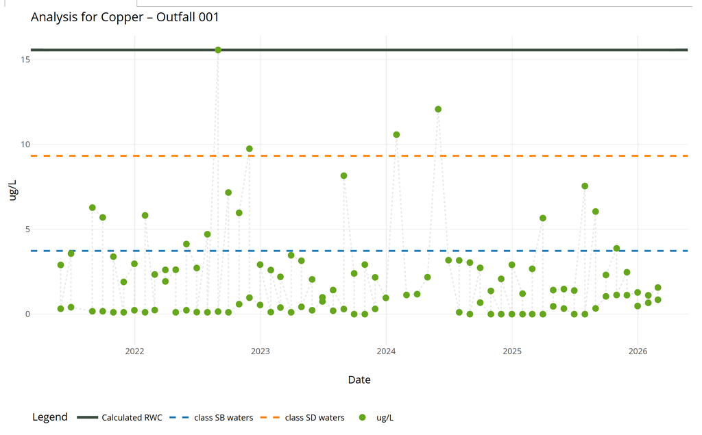

Observed vs. WQS/RWC plot with WQS dashed lines, solid RWC line, and sample points colored by unit

When the crosswalk carries a criterion-specific note for the parameter — for example, the dissolved-oxygen Streeter-Phelps note or the Enterococci interval note — it appears below the plot in a cream-colored box with a goldenrod left border.

For hardness-dependent metals in Class SD with **Show hardness range analysis** ticked (Section 4.6.3), a toggle above the plot switches between *Observed vs WQS/RWC* and *Hardness vs Limit*, and the observations view is annotated with the hardness below which the RWC would exceed the criterion.

## Direct-Comparison Plots and the Dissolved-Oxygen Case

Because a floor criterion reads “backwards” from a ceiling, the dissolved-oxygen plot is the clearest illustration of direct comparison: the criterion is a **floor** (a value below the line is the violation), and the observed minimum is what matters. The plot shows the DO observations against the 5.0 mg/L floor line, with the DO criterion note below it, and no Calculated RWC line (a DO analysis needs Streeter-Phelps inputs the app does not carry — see Section 8.2.3).

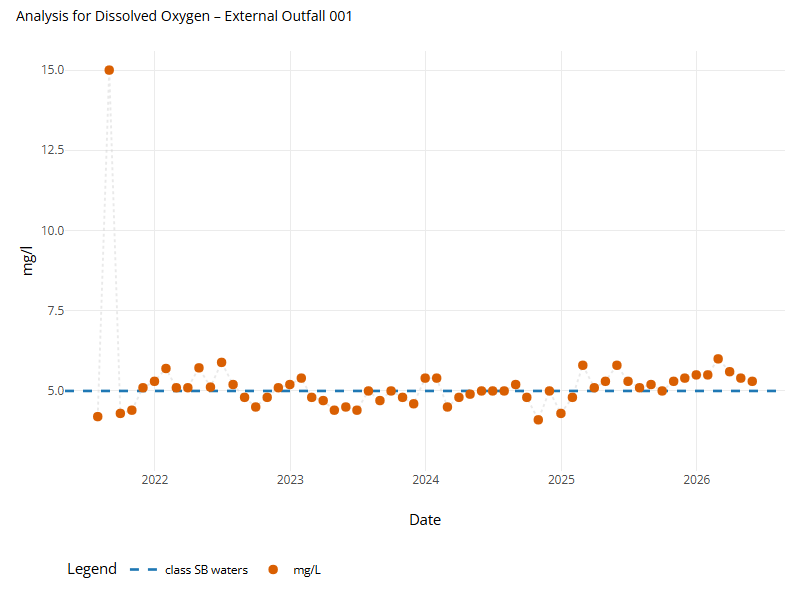

A dissolved-oxygen Inspector plot: the 5.0 mg/L criterion is a floor, observations below the line are the violation, and there is no RWC line

## Log Axis and Non-Detects

When the observed values sit far above a very small criterion, a linear axis collapses the criterion line onto zero and the plot looks blank. The app guards against this:

- When the observed maximum is **100× the criterion or more**, the y-axis switches to a log scale and the axis label gains “(log scale).” This is common and expected rather than a warning about the data. Bacteria counts span five or six orders of magnitude by nature, and human-health criteria for carcinogens are set far below any achievable laboratory quantitation limit — criteria in the crosswalk run down to $5.1\times10^{-8}$ µg/L for 2,3,7,8-TCDD, so any reported detection clears the threshold. A log axis simply keeps the criterion line and the observations visible in the same frame.
- Non-detects (NODI codes **B** and **Q**) are stored as a value of zero, and a log axis cannot display zero. On a log plot they are drawn as **open downward triangles** at a floor equal to the smallest positive value in the series, and the plot discloses that floor — in the axis label in the app, and in the figure caption in the PDF report. A triangle marks a value known only to be *below* the reporting limit; never read it as a measurement.
- If every observation is a non-detect, no positive value exists to compare against the criterion, so the plot stays on a linear axis and the points render normally at zero.

Note that this ratio is **not** a units check. Reported units are reconciled against the criterion’s units before plotting (see Section 9.4), so a wide gap on the plot is not by itself evidence of a reporting error. The parameters that trigger the log axis most often — Enterococci, fecal coliform, sulfide, sulfate — are wide-range by nature, and the same log axis and non-detect markers are mirrored in the PDF report.

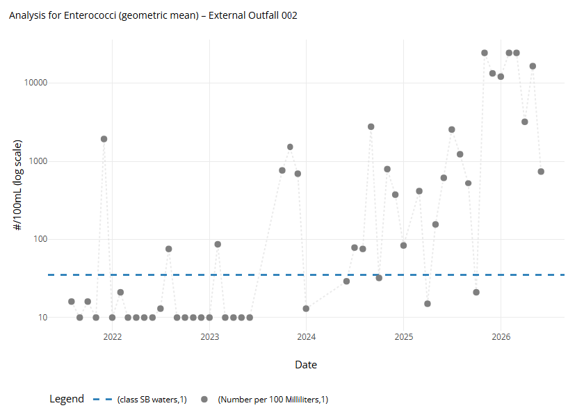

An Enterococci plot on a log-scale y-axis, keeping the criterion line and observations spanning several orders of magnitude in the same frame

# Report Generation

## Download Options

Click **Download Report** in the bottom bar of the Findings page. Two download formats are available:

**PDF only (default):** A single PDF report, `RP_Report_<permit>_<date>.pdf`, that documents all analysis inputs, settings, and findings in a format suitable for inclusion in a permit record.

**PDF + Data (ZIP):** Tick **Include Data in Download** before clicking Download Report. The app bundles the PDF together with:

- `data.xlsx` — an Excel workbook with five sheets: *Summary_Findings* (one row per finding), *RP_Concentration* (the full RP results with every intermediate value), *DMR* (the DMR records used, after unit conversion and code merging, with the original parameter code), *Coverage* (the NPDES forms coverage table), and *WQS_Info* (the criteria in effect for the run, including any manual entries)
- `README.txt` — the permit ID, tool version, date range, and hardness used

Use the ZIP option when you want to archive the underlying data alongside the report, or when the findings will be reviewed by others who need the raw numbers.

**Note**

**Report generation time:** Rendering the PDF runs a Quarto document with a plot for every pollutant × outfall combination. For facilities with many parameters and multiple outfalls, this can take 30–90 seconds. A progress indicator is displayed during rendering. Do not close the browser tab while the report is generating.

## Report Contents

The report opens with a title page and every section starts on a new page. Every page after the first carries a header (EPA Region 2, the report name, and the permit number) and a footer (the date generated, the tool version, and *Page X of Y*). The report is designed to remain readable when printed in black and white.

[figure not shown]

The report title page: logo and title, permit and facility band, monitoring period, application forms, generation date, and tool version

**Title page:** The permit number and facility name, the monitoring period, the application forms selected, the date generated, the tool version, and the table of contents.

**1 Summary:** Permit, facility, date range, water classes, forms, dilution ratio, confidence level, target percentile, and hardness setting. If the report was produced by Quick Run with unresolved parameters, a prominent preliminary-report warning appears here. The *Included Pollutants* table lists each pollutant with data and its *Basis for Inclusion*: required by a selected form, *Existing DMR* (prior data but not required by a selected form), or *Manually Added* (user-supplied data only). A † marks a manually entered WQS criterion and a ‡ marks a record supplemented with user-appended data.

**2 RP Findings:** All results in one table, ordered YES, then DEPENDS, then NO. A **Basis** column distinguishes *Calculated* (a projected RWC) from *Observed max/min* (a direct comparison), so an observed dissolved-oxygen minimum can’t be misread as dilution-adjusted.

**3 Non-Concentration Based Measures:** Every parameter assessed by direct comparison — pH, temperature, dissolved oxygen, Enterococci, color, turbidity, oil & grease (Section 8.2). Organized by parameter, then outfall.

**4 Concentration Based Measures:** Every parameter assessed by statistical projection, starting with the RP equations. Organized by parameter, then outfall.

Sections 3 and 4 share one layout. Each parameter starts with any criterion note from the crosswalk (an orange **Note**) and, where applicable, a *Manual WQS Applied* callout; section 3 parameters also state how the observed value is compared. Then, for each outfall:

- A **summary table** with one row per water class: WQS ID, water class, number of samples, whether units were converted, the WQS criterion, the RWC (section 4) or the observed minimum/maximum (section 3), and the RP result. pH has a row for each bound (Min and Max).
- A **plot** titled with the parameter and outfall, showing the observations against each class’s criterion line and, in section 4, the calculated RWC line. The log axis and non-detect markers follow the same rules as the app (Section 6.4).
- In section 4 only: the step-by-step **RWC Calculation** ($\sigma_g$, $p_n$, $z_p$, $z_{target}$, MF, RWC), the **Hardness vs WQS Criterion** curve for Class SD metals when the hardness range analysis is ticked, and the **Permit Effluent Limit History** for that outfall when the DMR records carry limits (mass-load limits are listed separately as not used in the WQS analysis).

A red **Check data** callout appears above the table when an outfall’s temperature values fall below 0 °C, which usually means Celsius values were reported under the Fahrenheit code (see Section 4.3). The values are shown as converted; verify them against the DMR.

[figure not shown]

A parameter section of the report: criterion note, summary table, and titled plot

**5 Parameters from Applications without DMR Data:** Pollutants required by the selected application forms for which no DMR data were found.

**6 Excluded Parameters:** Parameters excluded on the Needs Attention tab, with the flag reason and the reason given for exclusion (including those auto-excluded by Quick Run).

**7 Manual WQS Overrides:** Every manually entered criterion — value, unit, water classes, criterion type, and the basis/notes — for the permanent record.

# Methodology

This section describes the statistical and regulatory methods used by the app to evaluate reasonable potential. It covers the projection approach used for most parameters, the direct-comparison parameters that bypass it, the hardness-dependent metals, and Total Ammonia Nitrogen.

## The Statistical Projection Approach (TSD Section 3.3.2)

The fundamental question in an RP determination is whether the effluent, after accounting for dilution, could cause an exceedance of the applicable criterion in the receiving water. The challenge is that effluent concentrations are variable — a single measured maximum may not represent the true upper bound of what the discharge is capable of producing.

EPA’s TSD addresses this by treating the effluent concentration data as a sample from an underlying lognormal distribution and projecting the upper bound of that distribution at a specified confidence level. This approach simultaneously accounts for **data uncertainty** (a small number of samples represents the highest value less reliably than a large number does) and estimates the **statistical upper bound** of the effluent distribution at a user-specified probability level (the target percentile). The result is a Multiplying Factor (MF) applied to the observed maximum concentration before comparing to the criterion.

### The Multiplying Factor

The MF is derived in two steps following Box 3-2 of the TSD.

**Step 1 — Percentile represented by the maximum observation.** For a dataset of $n$ samples at confidence level CL, the highest observed value exceeds the $p_n$-th percentile of the underlying distribution with probability CL, where:

$$p_n = (1 - CL)^{1/n}$$

For example, with $n = 10$ samples and CL = 0.95, the maximum value exceeds approximately the 74th percentile of the distribution with 95% confidence.

**Step 2 — Project from the observed percentile to the target percentile.** Assuming a lognormal distribution for the effluent:

$$MF = \exp\left[(z_{target} - z_p) \cdot \sigma_g\right]$$

where $z_{target}$ is the standard normal variate corresponding to the target percentile, $z_p$ is the standard normal variate corresponding to $p_n$, and $\sigma_g = \sqrt{\ln(CV^2 + 1)}$ is the geometric standard deviation of the lognormal distribution expressed via the coefficient of variation (CV).

The **coefficient of variation** is estimated as $CV = s / \bar{x}$, where $s$ is the sample standard deviation and $\bar{x}$ is the sample mean. For datasets with fewer than 10 samples, the CV cannot be estimated reliably from the data alone, and the app assigns a default CV of **0.6**, consistent with the TSD recommendation and EPA’s national characterization of effluent variability.

The MF is bounded to be no less than 1. An MF below 1 would imply the maximum observed value already exceeds the target percentile — in which case no upward projection is needed and the maximum value itself is used.

### The Receiving Water Concentration

For projected criteria, the RWC is:

$$RWC = \frac{C_{max} \times MF}{DR}$$

where $C_{max}$ is the maximum observed effluent concentration (in WQS units), MF is the multiplying factor, and DR is the dilution ratio. The RP finding is YES if RWC > criterion for any applicable water class.

### Worked Example

Consider a facility with 8 observations of a pollutant at an outfall, with a maximum of 45 µg/L, a mean of 18 µg/L, and a standard deviation of 12 µg/L. Analysis settings are CL = 0.95, target percentile = 0.95, and DR = 1. Assume the criterion is 36 µg/L.

## Direct-Comparison Parameters

Some criteria are not maximum-concentration ceilings and are not meaningfully projected through the multiplying factor. For these, the app compares the appropriate observed statistic to the criterion directly: **no MF is applied and the dilution ratio is not used.** Each crosswalk row declares whether it is a ceiling (RP if the value exceeds the criterion) or a floor (RP if the value falls below it). The comparison is a **strict inequality** — a value exactly on the criterion is treated as compliant, matching the regulatory wording (“shall not exceed,” “shall not contain less than,” “outside the range of”). A small relative tolerance guards the comparison against floating-point and unit-conversion noise at the boundary.

Several of these parameters return **DEPENDS** rather than **NO** when no excursion is observed, because a screening-level end-of-pipe comparison cannot, by itself, rule out reasonable potential.

### pH

The PRWQSR establishes pH ranges rather than absolute concentration limits. For Class SD the standard is 6.0–9.0 SU (Rule 1303.2(C)(2)(d)); for Class SB it is 7.3–8.5 SU (Rule 1303.2(B)(2)(d)). pH is evaluated like any other direct parameter: when the selected water class has a pH criterion, the app compares the observed pH range to the standard and reports the result as separate *pH (maximum)* and *pH (minimum)* rows. An observed maximum above the upper bound, or an observed minimum below the lower bound, yields a **YES**; a value exactly on a bound is compliant. This is a direct comparison of observed pH to the standard, not a statistical RWC projection. pH values are also still used to compute the TAN criterion (see Section 8.4). If the selected class has no pH criterion, pH instead surfaces on the Needs Attention tab like any other unmatched parameter.

### Temperature

The PRWQSR’s thermal standard states that no heat shall be added that would cause the temperature of **any site** to exceed 30 °C / 86 °F (Rule 1303.1(D)(1)). Temperature (00010) is evaluated as a direct ceiling: **YES** if the observed maximum exceeds 30 °C, **DEPENDS** otherwise. The DEPENDS outcome reflects that this is an **in-stream** standard, not an end-of-pipe limit — an end-of-pipe comparison is screening only, so the absence of an exceedance at the pipe does not rule out RP in the receiving water. A note to this effect appears on the Findings page and in the report. The temperature criterion is a general surface-water standard, so it applies only when “Surface Waters” or “All” is selected (see Section 2.3); for other classes, temperature is flagged on the Needs Attention tab, where a manual criterion entered for it is still evaluated by direct comparison.

Temperature reported in °F (code 00011) is converted to °C before comparison (see Section 4.3). If the converted values fall below 0 °C, the report flags the outfall for a data check.

### Dissolved Oxygen

Dissolved oxygen (00300) is a **floor**: the receiving water must not fall below 5.0 mg/L, so the compliance-relevant statistic is the observed **minimum**, not the maximum. DO is evaluated by direct comparison — **YES** if the observed minimum is below 5.0 mg/L, **DEPENDS** otherwise — and no RWC is calculated.

**Important**

**Why DO is not projected.** Applying the TSD multiplying factor to DO is wrong in three ways: it projects an *upper* bound when DO needs a *lower* bound; the MF is derived for an upper percentile; and dilution does not attenuate a dissolved-oxygen deficit the way it attenuates a pollutant. A defensible DO analysis requires the Streeter-Phelps equation, whose inputs (reaeration and deoxygenation rates, travel time, upstream deficit) are not present in ICIS-NPDES. The app therefore screens the observed minimum against the floor and returns DEPENDS when no excursion is seen, with a note pointing to the Streeter-Phelps data gap.

### Color and Turbidity

Color (00080) and turbidity (00070) are direct **ceilings**: color at 15 color units (Class SD); turbidity at 50 NTU (Class SD) and 10 NTU (Class SB). Both are compared directly to the observed maximum.

### Enterococci

The PRWQS Enterococci criterion for SB/SD waters is **interval-based**: a geometric mean of 35 per 100 mL over any 90-day interval, plus a 90th-percentile criterion of 130 per 100 mL. These are frequency- and interval-based statistics, not maximum concentrations, so the multiplying-factor projection is not a meaningful operation on them. The app splits Enterococci into two direct rows (geometric mean and 90th percentile) evaluated against their own DMR statistics, returns **DEPENDS** when no excursion is observed, and carries a note instructing the permit writer to evaluate the geometric mean and 90th percentile over the applicable 90-day intervals independently. Alternate DMR codes for Enterococci are recognized so the criterion matches regardless of which code the permittee reported.

### Oil & Grease

Oil & grease is governed by a **narrative** standard (Rule 1303.1.H): waters shall be substantially free from oils and greases. There is no numeric value, so the app treats it as a **binary detection** test — any positive reported value triggers RP. Four oil & grease method codes are recognized, each carrying its own display label so they don’t collapse into a single confusing entry. As a general surface-water standard, oil & grease appears only when “Surface Waters” or “All” is selected.

### Surfactants (MBAS)

Surfactants as MBAS carry a numeric standard in Class SB (500 µg/L) and Class SD (100 µg/L), which is evaluated by statistical projection like any other concentration criterion. Only the Class SG “shall not be present” standard is a direct comparison: like oil & grease, it is a detection test, so any positive reported value triggers RP. The criterion is recognized under both the methylene-blue-active-substances code and the surfactants code the permittee may report under, so the same analyte matches regardless of which code appears in the DMR.

**Note**

**Synonym parameter codes.** A recurring data issue is the same analyte reported under a DMR code different from the one the criterion is stored under, which causes a silent non-match. Confirmed cases (ammonia, Enterococci, surfactants, sulfate) are aligned so the criterion applies to either code. Other candidates that carry a regulatory judgment — e.g., dissolved vs. total metal fractions, hexavalent vs. total chromium — are deliberately routed to the Needs Attention tab with a green hint rather than auto-matched, so the permit writer resolves the distinction.

## Hardness-Dependent Metal Criteria

Seven metals in Class SD waters have criteria that depend on receiving water hardness under Rule 1303.1(J)(1) of the PRWQSR. The criterion is a function of the natural logarithm of hardness expressed in mg/L as CaCO₃:

$$\text{Criterion} = e^{(LC \cdot \ln(H) - RC)}$$

where $H$ is the receiving water hardness and $LC$ and $RC$ are regression constants specific to each metal, taken directly from the PRWQSR footnotes to Table 1 in Rule 1303.1(J)(1):

| Metal | CRITERION_ID | LC | RC |
| --- | --- | --- | --- |
| Cadmium | 79228 | 0.7977 | 3.909 |
| Chromium III | 79238 | 0.8190 | 0.6848 |
| Copper | 79236 | 0.8545 | 1.702 |
| Lead | 79253 | 1.273 | 4.705 |
| Nickel | 79248 | 0.8460 | 0.0584 |
| Silver | 79251 | 1.72 | 6.59 |
| Zinc | 79264 | 0.8473 | 0.884 |

The app computes the criterion at the hardness entered in the Analysis Settings and uses it in the RP comparison. When the hardness range analysis is ticked, the plots also show the **critical hardness** — the hardness at which the criterion would equal the RWC — by inverting the formula:

$$H_{critical} = e^{\left(\ln(RWC) + RC\right) / LC}$$

If $H_{critical}$ is below the plausible range for the receiving water (e.g., below 25 mg/L as CaCO₃), reasonable potential is unlikely regardless of hardness. If it is within or above the plausible range, the result depends on the actual hardness, and the permit writer should use a site-specific hardness value (see Section 9.2).

## Total Ammonia Nitrogen (TAN)

Total Ammonia Nitrogen in **Class SD** surface waters is subject to a criterion that varies with the pH and temperature of the receiving water, as specified in Rule 1303.2(C)(2)(l) of the PRWQSR. (TAN is Class SD only — there is no Class SB TAN criterion.)

$$TAN = 0.8876 \times \left(\frac{0.0278}{1 + 10^{7.688 - pH}} + \frac{1.1994}{1 + 10^{pH - 7.688}}\right) \times \left(2.126 \times 10^{0.028 \times (20 - T)}\right)$$

where $T$ is the receiving water temperature in °C and the result is expressed as mg/L as N. The formula reflects the toxicity of un-ionized ammonia (NH₃) to aquatic life, which increases as pH and temperature rise.

**Parameter codes included.** The app coalesces three interchangeable ammonia codes into a single total-ammonia-as-N series before evaluation:

| Parameter Code | Description | Handling |
| --- | --- | --- |
| 00610 | Nitrogen, ammonia total [as N] | Canonical code |
| 82230 | Ammonia & ammonium — total | Coalesced to 00610 |
| 00609 | Ammonia nitrogen, total [as N] | Coalesced to 00610 |

**Single fixed limit.** The TAN criterion is computed once, from the receiving water pH and temperature entered in the Analysis Settings (Section 4.6.4), and compared with the TAN RWC. DMR pH and temperature records are not used for this. Because the TAN criterion is computed at run time rather than stored as a fixed value, TAN is never flagged on the Needs Attention tab.

# Interpreting Results and Common Cases

## Multiple Water Classes Selected

When more than one water classification is selected, the Findings table and the report list each class as a separate row for each pollutant and outfall, making it easy to see which classes drive a YES finding. The Inspector plot shows a separate dashed criterion line for each class, drawing the selected row’s criterion thicker, and its title gives the worst-case RP across the classes.

A common scenario is selecting both Class SB and Class SD when a facility may discharge to either coastal or surface receiving waters depending on the outfall. The more protective of the two criteria drives the worst-case RP result.

## Using the Hardness Range Analysis (Class SD Metals)

The RP result for a hardness-dependent metal is always computed at the hardness entered in the Analysis Settings, so it is only as good as that value. When no site-specific hardness is available, tick **Show hardness range analysis** to see how sensitive the result is:

1. **Use a site-specific hardness value where you can:** Obtain a measured or representative hardness for the receiving water (from ambient monitoring, the permit record, or DNER), enter it in the Hardness setting, and re-run.
2. **Use the critical hardness:** Read the annotation on the Findings plot (or the caption in the report): it gives the hardness below which the RWC would exceed the criterion. If that hardness is well below the plausible range for the receiving water, the result is not sensitive to the hardness assumption. If it is within the plausible range, the finding depends on the actual hardness. Document the basis for the hardness assumption in the permit record.

## Direct-Comparison Parameters Returning DEPENDS

Dissolved oxygen, temperature, and Enterococci return **DEPENDS** rather than **NO** when no excursion is observed. This is deliberate: for these parameters an end-of-pipe screen cannot rule out reasonable potential on its own (DO needs a Streeter-Phelps analysis, temperature is an in-stream standard, and the bacteria criteria are interval statistics). Treat a DEPENDS here as “not shown to be a problem by this screen, but not cleared” and resolve it with the additional analysis the criterion note describes.

## Unit Conversion Issues

A FAIL or FAIL (Partial) unit status means the app could not convert some or all reported values to the WQS unit. This does not stop the analysis — non-convertible records are dropped from the RP calculation and values are retained at face value elsewhere — but the result for that parameter should be interpreted with caution. Common causes:

- **Unusual units in the DMR:** Some submissions use non-standard unit abbreviations the app does not recognize. If you can confirm the unit is equivalent, the face value is correct.
- **Genuine unit mismatch:** The permittee reported a value in a genuinely different unit (e.g., a mass load where a concentration was expected). In that case the face value is meaningless and the parameter should be flagged for investigation.

Note that not every non-PASS status is a data problem. **EXCLUDED** means the parameter was reported in a mass-load or flow unit that cannot be compared to a concentration criterion — expected for load-based parameters. **NO WQS** means there is simply no criterion for the parameter in the selected class; use the Needs Attention tab to add one if appropriate. Only **FAIL** and **FAIL (Partial)** indicate an unrecognized unit that warrants investigation.

## Reading a Log-Scale Plot

A log axis means the observations and the criterion are separated by two or more orders of magnitude. That is usually real. Bacteria, sulfide, and sulfate routinely run thousands of times their criteria, and criteria for PCBs, dioxin, and the chlorinated pesticides sit below what any laboratory can quantify, so any reported detection clears the threshold.

Reporting-unit errors do occur, but the app reconciles reported units against the criterion’s units before plotting (see Section 9.4), so a wide gap is not by itself evidence of one. Verify units when a result is surprising for other reasons — not because the axis is logarithmic.

Read the open downward triangles with care. They mark non-detects, which carry no measured value; they are drawn at a plotting floor purely so they remain visible on a log axis, and the stated floor is the smallest positive value in that series, not a detection limit reported by the laboratory. A non-detect is a valid **NO** finding and the permit writer needs to see it, but its position on the y-axis carries no information.

## No Data for a Parameter

If a pollutant has no observations at an outfall, no row appears in the Findings table for that combination. This can occur when the parameter was not monitored at that outfall in the date range, the parameter code in the crosswalk does not match the code used in the DMR (a synonym-code issue — check the Coverage Summary and the Needs Attention hint), or the data were submitted under a different outfall identifier. A parameter required by the selected form but with no data appears in the Coverage Summary with a **NO DATA** status and a sample count of 0.

## Prior Permit Limits

The brown dot-dash line on the Findings plot, and the Permit Effluent Limit History table in the report, show the numeric effluent limits recorded in the DMR records for the parameter and outfall. They reflect the limits in the prior permit, not limits calculated by this app, and are provided as a reference point for comparing the current RP analysis to existing permit conditions.

## Appendix A: Where to Find the Criteria

The criteria the app applies come from a crosswalk between DMR parameter codes and the PRWQSR criteria. The pollutants each NPDES application form requires come from a separate form table. Neither is reproduced here, because both are easier to search in the app:

- **WQS Reference tab** (Summary page) — the full crosswalk: every parameter code, criterion ID, criterion value, unit, water class, and the stream vs. reservoir/lake distinction under Class SD. Use it to confirm criterion IDs and values before entering a manual criterion (Section 4.5).
- **Coverage Summary** (Data Overview tab) — the pollutants the selected forms require, whether each has data, and its unit status (Section 4.4).
- **WQS_Info sheet** of the data package — the criteria actually in effect for a given run, including any manual entries (Section 7.1).

Pollutants required by a form that have no corresponding WQS criterion are listed in the Coverage Summary; they are not evaluated for RP automatically, but a criterion can be supplied for them on the Needs Attention tab.

## Appendix B: Technical References

The following documents provide the regulatory and methodological basis for the RP Calculator.

**EPA (1991).** *Technical Support Document for Water Quality-Based Toxics Control.* EPA/505/2-90-001. Office of Water, U.S. Environmental Protection Agency, Washington, D.C. Section 3.3.2 — Statistical Projection of Upper-Bound Effluent Concentrations.

**DNER (2025).** *Puerto Rico Water Quality Standards Regulation, as Amended April 2025.* Resolution R-25-006. Puerto Rico Department of Natural and Environmental Resources, San Juan, PR. Filed with the Puerto Rico Department of State June 27, 2025 (Number 9677).

**40 CFR 122.44(d)(1).** *Conditions applicable to all permits — Technology-based and water quality-based effluent limitations.* Code of Federal Regulations, Title 40, Part 122.

**40 CFR 131.** *Water Quality Standards.* Code of Federal Regulations, Title 40, Part 131.

## Appendix C: Glossary

**Ceiling criterion:** A criterion the discharge must not exceed. Reasonable potential exists if the assessed value is above the criterion (a strict “greater than” test).

**Coefficient of Variation (CV):** The ratio of the standard deviation to the mean for a dataset, used in the MF calculation as a measure of relative effluent variability. When $n < 10$, the app assigns a default CV of 0.6 per TSD guidance.

**Confidence Level (CL):** The probability that the highest observed value in a sample of $n$ exceeds a given percentile of the underlying distribution. Defaults to 0.95 (95%).

**DEPENDS:** An RP determination returned when no excursion was observed but the absence of one cannot, by itself, rule out reasonable potential — used for direct parameters such as dissolved oxygen, temperature, and Enterococci.

**Direct comparison:** Evaluation of a criterion by comparing the appropriate observed statistic to the criterion value with no multiplying factor and no dilution ratio. Used for pH, temperature, dissolved oxygen, color, turbidity, Enterococci, oil & grease, and Class SG surfactants.

**DMR (Discharge Monitoring Report):** The periodic report submitted by NPDES permittees documenting effluent monitoring results. Sourced by the app from the local ICIS-NPDES database.

**Dilution Ratio (DR):** The ratio of the total receiving water flow (including the effluent) to the effluent flow alone at the point of compliance. Applied only to projected criteria.

**Floor criterion:** A criterion the receiving water must not fall below (e.g., dissolved oxygen). Reasonable potential exists if the assessed value is below the criterion (a strict “less than” test); the compliance-relevant statistic is the observed minimum.

**ICIS-NPDES:** EPA’s Integrated Compliance Information System for NPDES, the system of record for permit and DMR data. The app reads a weekly SQLite snapshot of the PR/VI portion of this database, built by `refresh_db.R`.

**MF (Multiplying Factor):** The statistical factor applied to the maximum observed effluent concentration to project the upper bound of the effluent distribution at the target percentile and confidence level. Bounded to be ≥ 1.

**NPDES (National Pollutant Discharge Elimination System):** The federal permitting program under the Clean Water Act that regulates point source discharges to waters of the United States.

**PRWQSR (Puerto Rico Water Quality Standards Regulation):** The water quality standards regulation administered by DNER. The 2025 amendment is the applicable version in this app.

**Reasonable Potential (RP):** Under 40 CFR 122.44(d)(1), the determination that a discharge causes, has the reasonable potential to cause, or contributes to an excursion above an applicable water quality standard. A YES RP finding triggers the requirement for a water quality-based effluent limitation.

**RWC (Receiving Water Concentration):** For projected criteria, the projected concentration in the receiving water after accounting for the statistical upper bound of the effluent distribution and the available dilution: RWC = (C_max × MF) ÷ DR. Not calculated for direct-comparison criteria.

**Statistic token:** A semantic label (daily maximum, daily minimum, geometric mean, 90th percentile, average) that governs both which DMR records are extracted and which value a criterion is compared against. Raw ICIS statistical-base codes are mapped to these tokens through a lookup table.

**TAN (Total Ammonia Nitrogen):** The sum of ammonium ion (NH₄⁺) and un-ionized ammonia (NH₃). Subject to a pH- and temperature-dependent criterion in Class SD waters under Rule 1303.2(C)(2)(l).

**Target Percentile:** The upper bound of the lognormal effluent distribution that the projected RWC is designed to represent. Defaults to 0.95 (95th percentile).

**TSD (Technical Support Document for Water Quality-Based Toxics Control):** EPA’s 1991 guidance document providing the statistical methodology for RP determinations using effluent monitoring data (EPA/505/2-90-001).

**WQS (Water Quality Standards):** A designated use or uses for a water body, the water quality criteria necessary to protect those uses, and an antidegradation policy. In this app, WQS refers specifically to the criteria established in the PRWQSR.

## Appendix D: Version History

The version is shown next to the app title, on the landing page, and on every report. It follows the pattern *major.minor.patch*: a patch release fixes errors without changing results that were correct, a minor release adds features, and a major release may change how determinations are made.

## Version 1.0.0

The first versioned release. Analyses run before version 1.0.0 carry no version number on the report. If you are relying on such a report, note the following changes in how results are determined, which were made before this release:

- **TAN criterion coefficient.** An earlier copy of the TAN formula omitted the leading 0.8876 coefficient, which inflated every computed TAN criterion by about 12.7% and made the standard more lenient than the regulation. Re-run any TAN determination made with an unversioned copy of the app.
- **Strict inequality.** Criteria are compared with a strict inequality, matching the regulatory wording: a value exactly on the criterion is compliant. This changed some pH results that were previously YES.
- **Direct-comparison parameters.** Dissolved oxygen, Enterococci, color, turbidity, oil & grease, pH, and temperature are evaluated by direct comparison rather than projected. Color and turbidity were previously missing from results altogether, and a permit reporting ammonia only under code 00609 previously produced no TAN evaluation.
- **Manually entered temperature criteria.** A temperature criterion entered on the Needs Attention tab for a class other than “Surface Waters” was projected through the multiplying factor instead of compared directly. It is now compared directly, like every other temperature criterion.

Also new in 1.0.0:

- A restructured report: a title page, a page header and footer, every section on a new page, direct-comparison parameters only in section 3, one summary table per parameter and outfall, titled plots, and a check-data flag for sub-zero temperatures (Section 7.2).
- The report now records the hardness setting actually used (reports previously always said *Range*), and the Hardness vs Limit view on the Findings page works again.
- DMR uploads accept dates as `YYYY-MM-DD` as well as `MM/DD/YYYY`, the template includes the outfall column, and appending a CSV without optional columns no longer fails.